# Praca domowa 2

Stefan Gajda

## Dane

Dane wykorzystane w Pracy domowej 2 opisują wycenę nieruchmości. Każda obserwacja jest pewną nieruchmością, która posiada informacje takie jak powierzchnia, liczba pokoi, liczba łazienek i wiele więcj. Opis wszystkich kolumn w pliku `README.md`.

## Zadanie 1

Jak wygląda rozkład ceny nieruchomości w poszczególnych kodach pocztowych na przestrzeni lat? Rozważamy kody pocztowe, które mają więcej niż 280 posiadłości.

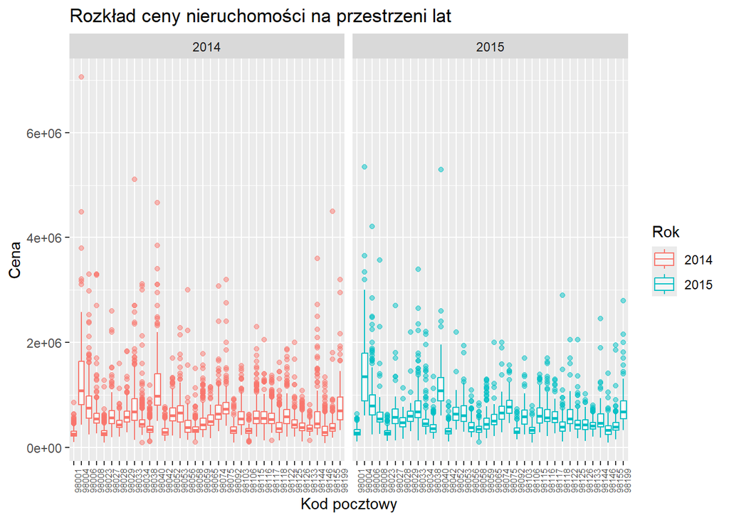

```r
# Tu umieść kod do wygenerowania odpowiedzi do zadania.
properties_prices<-df %>%
  group_by(zipcode) %>%
  mutate(count=n(),
         Year = substr(date, 1, 4))%>%
  filter(count>280)


  plot1 <- ggplot(data = properties_prices, aes(x = factor(zipcode), y = price,color=Year)) +
    geom_boxplot(alpha = 0.5) +
    facet_grid(~Year) +
    labs(title = "Rozkład ceny nieruchomości na przestrzeni lat",
       x = "Kod pocztowy",
       y = "Cena",
       color = "Rok") +
    theme(axis.text.x = element_text(angle = 90, hjust = 1,size=6))
plot1
```

**Komentarz: W roku 2014 sprzedawano dużo więcej domów o wyższych cenach, jeśli chodzi o domy w cenach niskich i średnich rozkład wygląda dość podobnie.**

## Zadanie 2

Czy jest różnica w rozkładzie ceny nierchomości od powierzchni mieszkalnej uwzględniając podział na nieruchomości z piwnicą i bez?

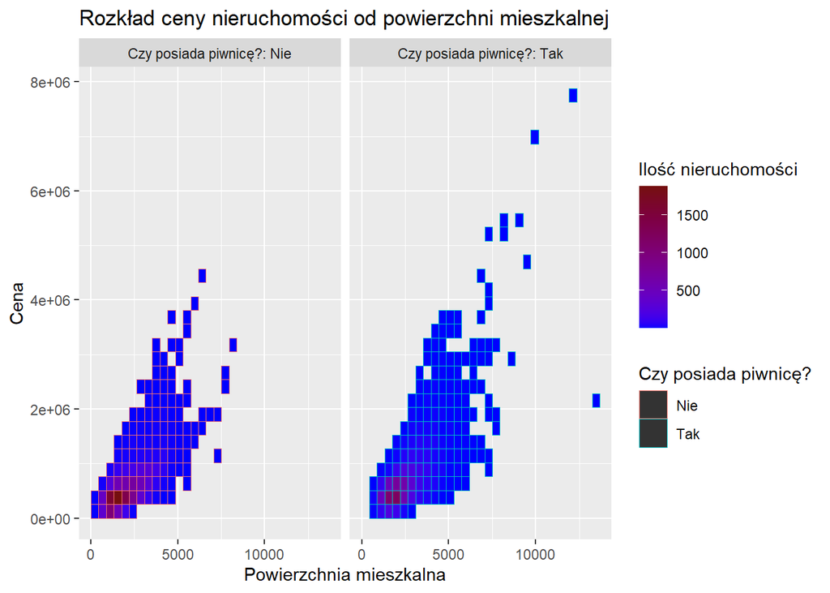

```r
# Tu umieść kod do wygenerowania odpowiedzi do zadania.
is_basement<-df %>%
  mutate(with_basement = ifelse(sqft_basement > 0, "Tak", "Nie"))
facet_labels <- as_labeller(c("Tak" = "Czy posiada piwnicę?: Tak", "Nie" = "Czy posiada piwnicę?: Nie"))

plot2<-ggplot(is_basement,aes(x=sqft_living,y=price,color=with_basement))+
  geom_bin_2d()+
  scale_fill_gradient(low = "blue", high = "#750f0f", name = "Ilość nieruchomości") + # Skala dla geom_bin_2d
  facet_wrap(~with_basement,labeller = facet_labels, strip.position = "top")+
  labs(title = "Rozkład ceny nieruchomości od powierzchni mieszkalnej",
       x = "Powierzchnia mieszkalna",
       y = "Cena",
       color = "Czy posiada piwnicę?")
plot2
```

**Komentarz: Stosunek powierzchni mieszkalnej do ceny jest dość podobny w obydwu przypadkach, wygląda to na wzrost liniowy. Pośród mieszkań bez piwnicy sprzedawano więcej mieszkań o mniejszej powierzchni, pośród tych posiadających piwnicę jest dużo większy zakres powierzchni które są oferowane.**

## Zadanie 3

Jaka jest zależność pomiędzy jakością wykończenia nieruchomości a liczbą pięter?

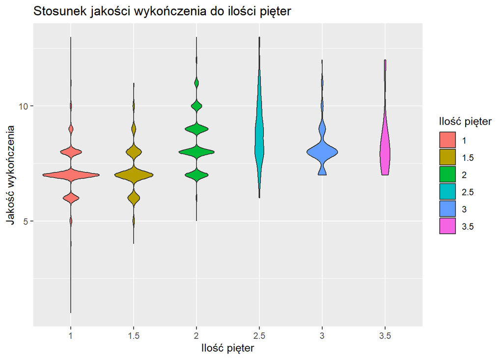

```r
# Tu umieść kod do wygenerowania odpowiedzi do zadania.
plot3<-ggplot(df,aes(x=factor(floors),y=grade,fill=factor(floors)))+
  geom_violin()+
  labs(title="Stosunek jakości wykończenia do ilości pięter",
       x="Ilość pięter",
       y="Jakość wykończenia",
       fill="Ilość pięter")

plot3
```

**Komentarz: Dla budynków o większej ilości pięter zwiększa się minimalna jakość wykończenia. Dla nieruchomości o każdej ilości pięter są budynki o najwyższych ocenach jakości budynku (>=10)**

## Zadanie 4

Jaka jest zależność między powierzchnią mieszkalną nieruchomości a powierzchnią gruntu w podziale na liczbę sypialni?

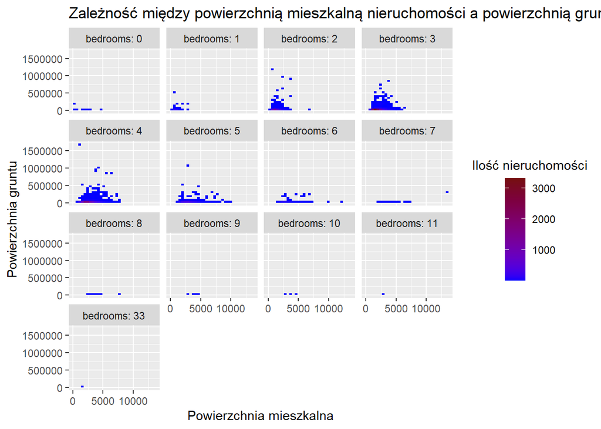

```r
# Tu umieść kod do wygenerowania odpowiedzi do zadania.
plot4 <- ggplot(df, aes(x = sqft_living, y = sqft_lot, fill = after_stat(count))) +
  geom_bin_2d() +
  facet_wrap(~bedrooms,labeller = label_both, strip.position = "top") +
  scale_fill_gradient(low = "blue", high = "#750f0f", name = "Ilość nieruchomości") + # Skala dla geom_bin_2d
  theme(
    legend.position = "right",legend.box = "horizontal"
  ) +
  guides(
    fill = guide_colorbar(title.position = "top", title.hjust = 0.5))+
  labs(title="Zależność między powierzchnią mieszkalną nieruchomości a powierzchnią gruntu",
       x="Powierzchnia mieszkalna",
       y="Powierzchnia gruntu"
       )

plot4
```

**Komentarz: Im większa liczba sypialni tym wykres się spłaszcza. Może być to spowodowane istnieniem apartamentowców posiadających wiele sypialni, które mają dużą powierzchnię mieszkalną a zajmujących niewielką powierzchnię gruntu.**

## Zadanie 5

Rozważmy tylko nieruchomości, które miały remont. W której dekadzie było najwięcej przeprowadzonych remontów? Czy w poszczególnych dekadach jest porównywalny procent nieruchmości dla każdej wartości miary jakości i wykończenia nieruchomości?

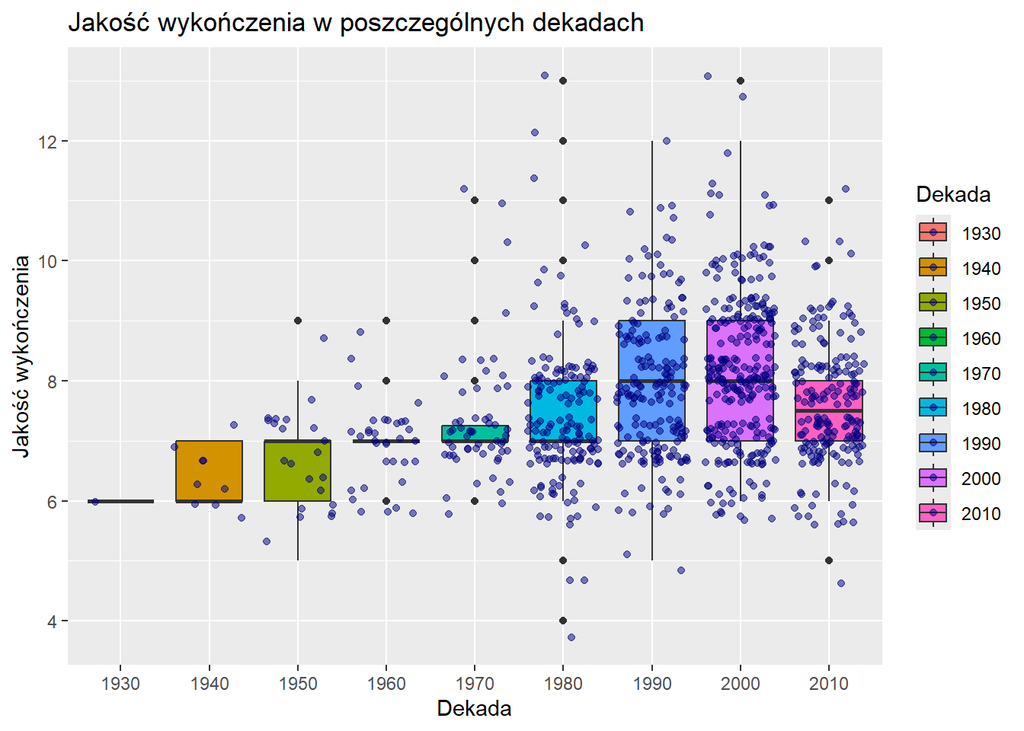

```r
# Tu umieść kod do wygenerowania odpowiedzi do zadania.
renovated_houses<-df %>%
  filter(yr_renovated!=0) %>%
  mutate(date = as.Date(date, format = "%Y%m%d"),
         decade=floor(yr_renovated/10)*10
         )


plot5<-ggplot(renovated_houses,aes(x=factor(decade),y=grade,fill=factor(decade)))+
  geom_boxplot()+
  geom_jitter(alpha=0.5,color="navyblue")+
  labs(
    title="Jakość wykończenia w poszczególnych dekadach",
    x="Dekada",
    y="Jakość wykończenia",
    fill="Dekada"
  )
plot5
```

## Zadanie 6

Jak prezentuje się wartość minimalna, średnia i maksymalna ceny nieruchmości w podziele na rok budowy nieruchomości.

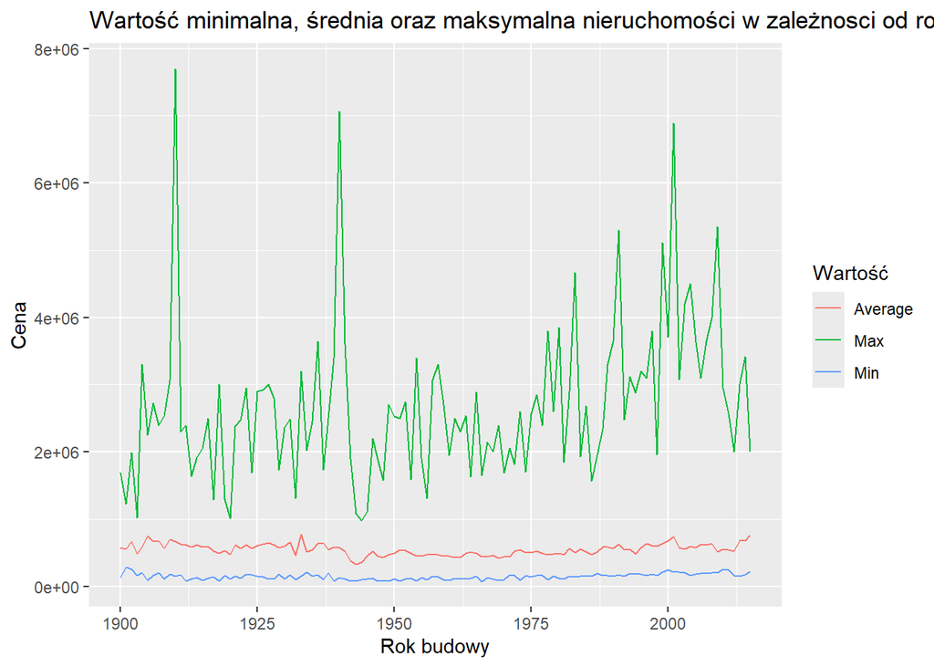

```r
# Tu umieść kod do wygenerowania odpowiedzi do zadania.
values<-df %>%
  group_by(yr_built) %>%
  summarize(Max=max(price),
         Min=min(price),
         Average=mean(price)) %>%
  pivot_longer(cols = c(Min, Average, Max),
               names_to = "price_type",
               values_to = "price")
plot6<-ggplot(values,aes(x=yr_built,y=price,color=price_type))+
  geom_line()+
  labs(title="Wartość minimalna, średnia oraz maksymalna nieruchomości w zależnosci od roku budowy",
       x="Rok budowy",
       y="Cena",
       color="Wartość")
plot6
```

**Komentarz: W kolejnych latach cena minimalna oraz średnia była na bardzo podobnym poziomie. Cena maksymalna miała dużo większe wahania z dużymi wzrostami w okolicy lat 1910,1940,2000.**